# **Lab 3 – Quantization and Color Histogram Equalization**

**Import the necessary libraries for Lab 3:**

```python
%matplotlib inline
import numpy as np
import cv2
import matplotlib.pylab as plt
from skimage import transform,io,color,img_as_ubyte
from sklearn import cluster
from sklearn.utils import shuffle
import math
```

# Part 1: Quantization

- Insert your function quant_img(img, N) from the preliminary report.

```python
def quant_img (img,N):
    #uniform quantization of an image to values [0,N]
    min_val=np.min(img)
    max_val=np.max(img)
    quant_range=(max_val-min_val)/N
    quant_uniform=min_val + np.floor((quant_range*np.floor_divide(img-min_val,quant_range)))
    #explanation: we normalize the values of the image to the window quant_uniform, and round down
    return quant_uniform
```

- Load the image of your choise as gray scale image and perform uniform quantization on your image to **2, 4, 8, 16, 32 and 64** gray levels.  
  From which quantization factor do you observe the problem of false contours? Attach relevant examples from the quantized images to demonstrate your answer.

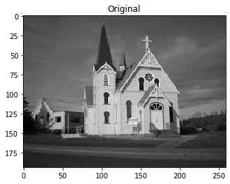

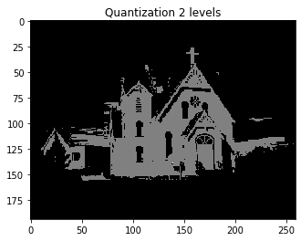

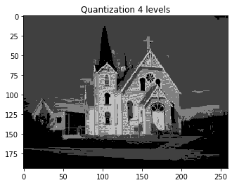

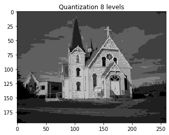

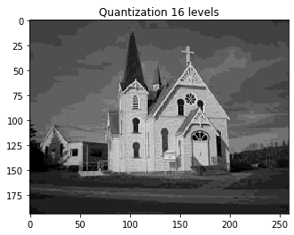

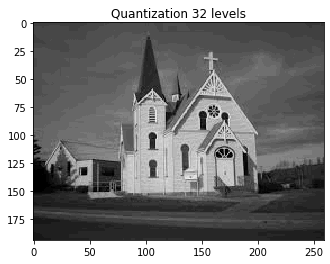

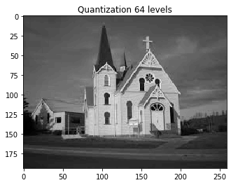

```python
img=plt.imread("house.jpg")
img=color.rgb2gray(img)
img=img_as_ubyte(img)


plt.title("Original")
plt.imshow(img,cmap='gray')
plt.show()

quant2=quant_img(img,2)
plt.title("Quantization 2 levels")
plt.imshow(quant2,cmap='gray')
plt.show()

plt.title("Quantization 4 levels")
quant4=quant_img(img,4)
plt.imshow(quant4,cmap='gray')
plt.show()

quant8=quant_img(img,8)
plt.title("Quantization 8 levels")
plt.imshow(quant8,cmap='gray')
plt.show()

quant16=quant_img(img,16)
plt.title("Quantization 16 levels")
plt.imshow(quant16,cmap='gray')
plt.show()

plt.title("Quantization 32 levels")
quant32=quant_img(img,32)
plt.imshow(quant32,cmap='gray')
plt.show()

quant64=quant_img(img,64)
plt.title("Quantization 64 levels")
plt.imshow(quant64,cmap='gray')
plt.show()
```

For 2,4,8,16 grey levels the False Countours effect occurs, for 32 and 64 levels the image looks more like the original

- Use the supplied function *imnoise()*, that adds Gaussian noise, on the image before quantization and test the effect on the false contours problem. Use zero mean noise with several values of variance.  
  You can use the quantization level that you chose in the previous section.

  What value of variance yields the optimal result? Attach examples of the quantized images with optimal and non-optimal variance values.

```python
def imnoise(img, mean, std):
    noisy_img = img + np.random.normal(mean, std, img.shape)
    return np.clip(noisy_img, 0, 255)  # keep the bounds
```

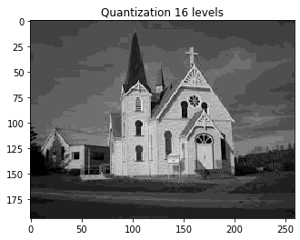

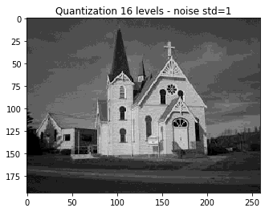

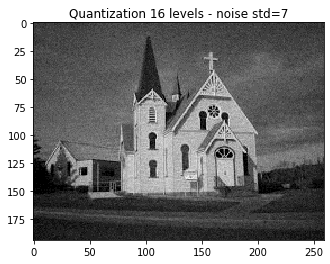

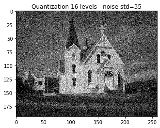

```python
noisy1=imnoise(img,0,1)
noisy10=imnoise(img,0,7)
noisy35=imnoise(img,0,35)

plt.title("Quantization 16 levels")
plt.imshow(quant16,cmap='gray')
plt.show()

q_noisy1=quant_img(noisy1,16)
plt.title("Quantization 16 levels - noise std=1")
plt.imshow(q_noisy1,cmap='gray')
plt.show()

q_noisy10=quant_img(noisy10,16)
plt.title("Quantization 16 levels - noise std=7")
plt.imshow(q_noisy10,cmap='gray')
plt.show()

q_noisy35=quant_img(noisy35,16)
plt.title("Quantization 16 levels - noise std=35")
plt.imshow(q_noisy35,cmap='gray')
plt.show()
```

We can see that noise reduces the False Contours problem. The optimal s.d. value is 7, below this value the noise is not significant enough to unsmooth the original image and above this value the noise overkill the image.

- **Bonus exercise** - perform quantization on your image by using K-means to **2, 4, 8, 16, 32 and 64** gray levels.  
  Compare your results to the results from the previous section.

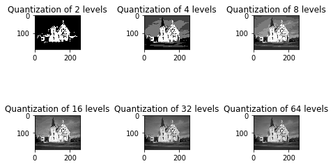

```python
m,n = img.shape

quant_levels = [2,4,8,16,32,64]
fig, axes = plt.subplots(nrows=2, ncols=int(len(quant_levels)/2))
ax = axes.ravel()

for num,N in enumerate(quant_levels):
    np.random.seed(0)

    image_array = img.reshape(-1,1)
    image_array_sample = shuffle(image_array, random_state=0)[:1000]
    kmeans = cluster.KMeans(n_clusters= N).fit(image_array_sample)

    labels = kmeans.predict(image_array)


    image = np.zeros((m,n))
    label_idx = 0
    for i in range(m):
        for j in range(n):
            image[i][j] = kmeans.cluster_centers_[labels[label_idx]]
            label_idx += 1
    ax[num].imshow(image, cmap='gray')
    ax[num].set_title("Quantization of {} levels".format(N))

plt.tight_layout(pad =0.05,w_pad=4)
plt.show()
```

# Part 2: Color Histogram Equalization

Use the supplied function hist_demo().

- Observe the following demonstrations:
  - Contrast stretching.
  - Histogram equalization.

```python
def hist_demo(img):
    # Contrast stretching
    img_dbl = np.float64(img)
    min_im = np.min(np.min(img_dbl))
    max_im = np.max(np.max(img_dbl))
    img_stretched_contrast = np.uint8(255*(img_dbl-min_im)/(max_im-min_im))

    # Histogram equalization
    img_hist_eq = cv2.equalizeHist(img)

    fig, axes = plt.subplots(nrows=1, ncols=2)
    ax = axes.ravel()
    ax[0].imshow(img, cmap='gray')
    ax[0].set_title("Original image")
    hist = cv2.calcHist([img],[0],None,[256],[0,256])
    ax[1].plot(hist)
    ax[1].set_title("Original image histogram")
    plt.tight_layout(); plt.show()

    fig, axes = plt.subplots(nrows=1, ncols=2)
    ax = axes.ravel()
    ax[0].imshow(img_stretched_contrast, cmap='gray')
    ax[0].set_title("Contrast stretching image")
    hist = cv2.calcHist([img_stretched_contrast],[0],None,[256],[0,256])
    ax[1].plot(hist)
    ax[1].set_title("Contrast stretching histogram")
    plt.tight_layout(); plt.show()

    fig, axes = plt.subplots(nrows=1, ncols=2)
    ax = axes.ravel()
    ax[0].imshow(img_hist_eq, cmap='gray')
    ax[0].set_title("Histogram equalization image")
    hist = cv2.calcHist([img_hist_eq],[0],None,[256],[0,256])
    ax[1].plot(hist)
    ax[1].set_title("Histogram equalization histogram")
    plt.tight_layout(); plt.show()
```

- Load a gray image of your choise and test these demonstrations. Make sure that the image you choose is indeed affected by both operations.  
  On which image contrast stretching won’t affect? On which image histogram equalization won’t affect?

  Note: If you are experiencing any errors, try to convert the image to uint8 with image_as_ubyte (as we did in the first lab) before using the suplied function.

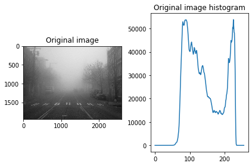

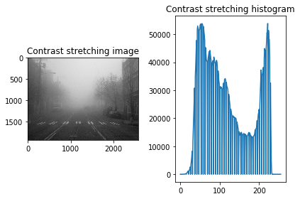

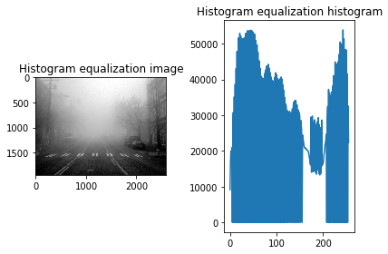

```python
img2=plt.imread("fog.jpg")
img2=color.rgb2gray(img2)
img2=img_as_ubyte(img2)

hist_demo(img2)
```

Contrast steching is not good for images where grey levels are spread through the entire grey level range in their histogram (i.e. images with already high contrast). We can see that for this fogged image, the histogram equalization and contrast streching method reveal a few new deatails in the image. Histogram equalization will not effect the image if the common grey values are already far away from each other (i.e. the histogram is uniformly distributed).

**Histogram Equalization**

1. Show the histogram-equalized color image. In this case, the histogram equalization is performed separately on all 3 layers (R, G, B). Use the supplied function hist_eq_rgb.

Note: In this section you should load a color image.

```python
# Supplied function -
def hist_eq_rgb(img):

    print("image shape: ", img.shape)
    plt.imshow(img)
    plt.show()
    R, G, B = cv2.split(img)
    R_eq = cv2.equalizeHist(R)
    G_eq = cv2.equalizeHist(G)
    B_eq = cv2.equalizeHist(B)


    fig, ax = plt.subplots(ncols=4, nrows=3, figsize=(30, 20))
    ax[0,0].imshow(R); ax[0,0].set_title('Red channel')
    ax[1,0].imshow(G); ax[1,0].set_title('Green channel')
    ax[2,0].imshow(B); ax[2,0].set_title('Blue channel')
    ax[0,1].hist(R.flatten(),256,[0,256], color = 'r'); ax[0,1].set_title('Red channel histogram')
    ax[1,1].hist(G.flatten(),256,[0,256], color = 'b'); ax[1,1].set_title('Green channel histogram')
    ax[2,1].hist(B.flatten(),256,[0,256], color = 'g'); ax[2,1].set_title('Blue channel histogram')

    ax[0,2].imshow(R_eq); ax[0,2].set_title('Red channel after histogram equalization')
    ax[1,2].imshow(G_eq); ax[1,2].set_title('Green channel after histogram equalization')
    ax[2,2].imshow(B_eq); ax[2,2].set_title('Blue channel after histogram equalization')
    ax[0,3].hist(R_eq.flatten(),256,[0,256], color = 'r');ax[0,3].set_title('Red channel histogram after histogram equalization')
    ax[1,3].hist(G_eq.flatten(),256,[0,256], color = 'b');ax[1,3].set_title('Green channel histogram after histogram equalization')
    ax[2,3].hist(B_eq.flatten(),256,[0,256], color = 'g');ax[2,3].set_title('Blue channel histogram after histogram equalization')



    img_eq = cv2.merge((R_eq,G_eq,B_eq))
    plt.figure()

    plt.imshow(img_eq)
    plt.title('The image after histogram equalization on all 3 layers (R, G, B)')
    plt.show()
```

```
image shape:  (500, 750, 3)
```

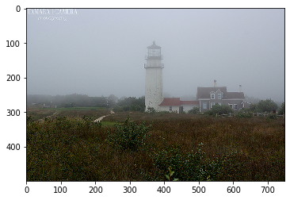

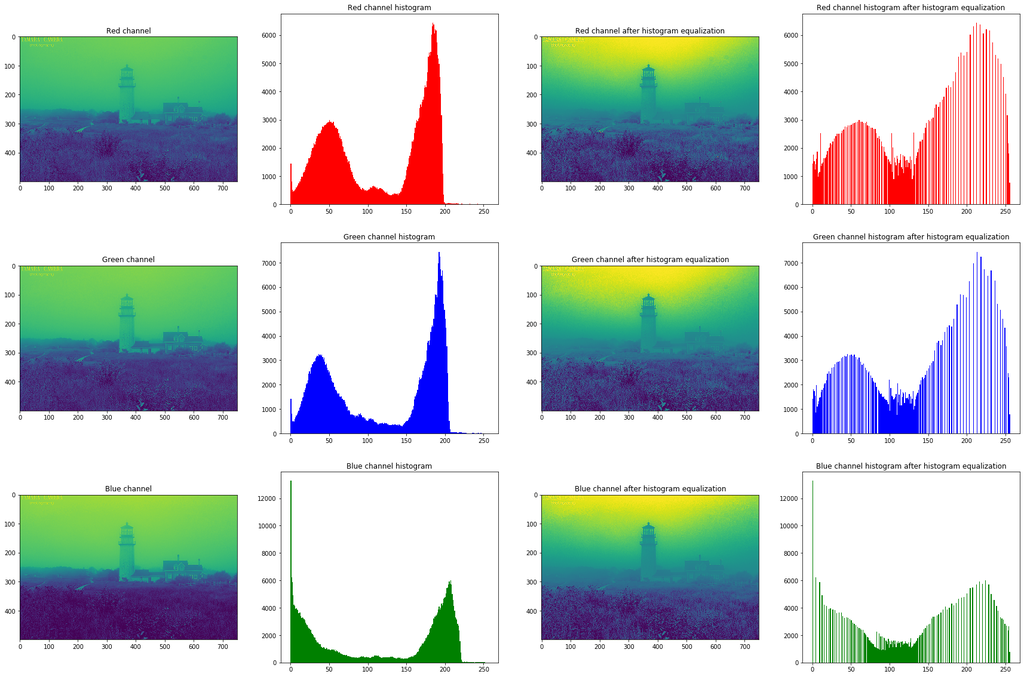

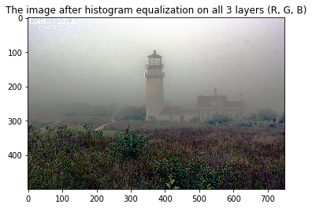

```python
img3=plt.imread("lighthouse.bmp")
hist_eq_rgb(img3)
```

We can see that the image dont looks as we wanted to, so we will try in other color space:

1. Perform histogram equalization each time on one of the **H, S, V** components (the other 2 components remain unchanged), generating 3 color images. (Hint: in order to display on the monitor the color image that was created in HSV space, you have to convert the image back to RGB space).

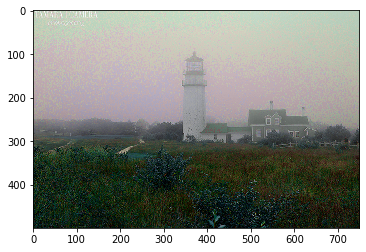

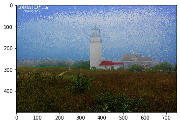

[figure not shown]

```python
img3=cv2.imread("lighthouse.bmp")
img3=cv2.cvtColor(img3,cv2.COLOR_BGR2HSV)
H, S, V = cv2.split(img3)
H_eq = cv2.equalizeHist(H)
S_eq = cv2.equalizeHist(S)
V_eq = cv2.equalizeHist(V)
img_h_eq = cv2.merge((H_eq,S,V))
img_h_eq=cv2.cvtColor(img_h_eq,cv2.COLOR_HSV2RGB)
img_s_eq = cv2.merge((H,S_eq,V))
img_s_eq=cv2.cvtColor(img_s_eq,cv2.COLOR_HSV2RGB)
img_v_eq = cv2.merge((H,S,V_eq))
img_v_eq=cv2.cvtColor(img_v_eq,cv2.COLOR_HSV2RGB)
plt.imshow(img_h_eq)
plt.show()
plt.imshow(img_s_eq)
plt.show()
plt.imshow(img_v_eq)
plt.show()
```

1. which method is better for performing an histogram equaliztion?

The historgram equalization on the V component is better, is keeps the original colors of the image and have better brightness. the other 2 equalizations change the colors of the original or oversaturating the image.